# HW5 GGPLOT Revisited

Q Liang

2/28/2024

# 1 Prepare a single data set

1. Reshape data set: Income Per Person to make a longitudinal data such that the resulting data set has three columns: country, year, and income.

```r
#Read income_per_person.
data0 <- read.csv ("/Users/qianshengliang/Dropbox/STA553/Week 5/income_per_person.csv",
                   header=TRUE,sep=",")
#change name.
colnames(data0)[which(names(data0) == "geo")] <- "country"
#names(data0)
#Wide_to_long reshape
data0a <- data0 %>%
 pivot_longer(
  cols = starts_with("X"),
  names_to = "year",
  names_prefix = "X",
  #names_transform = list(year = as.integer),
  values_to = "income",
  values_drop_na = TRUE)
#check
#head(data0a)
```

2. Do the same for Life Expectancy in Years so that the resulting data set has three columns: country, year, and life expectancy.

```r
#Read life_expectancy_years.
data1 <- read.csv ("/Users/qianshengliang/Dropbox/STA553/Week 5/life_expectancy_years.csv",
                   header=TRUE,sep=",")
#change name.
#data1[1:2,1:200]
#names(data0)
colnames(data1)[which(names(data1) == "geo")] <- "country"
#names(data0)
#Wide_to_long reshape
data1a <- data1 %>%
  pivot_longer(
    cols = starts_with("X"),
    names_to = "year",
    names_prefix = "X",
    #names_transform = list(Year = as.integer),
    values_to = "lifeExp",
    values_drop_na = TRUE)
#check
#head(data1a)
```

3. Merge/join the above two longitudinal data sets to make a new data set, under name LifeExpIncom that has variables: country, year, lifeExp, and income.

```r
Life0 <- left_join(data0a, data1a, by = c("country","year"))
#Life0
```

4. Merge LifeExpIncom with country region so that the final data set has information about income, life expectancy, and country region.

```r
#Read countries_total.
data2 <- read.csv ("/Users/qianshengliang/Dropbox/STA553/Week 5/countries_total.csv",
                   header=TRUE,sep=",")
#data2
#change name
#names(data2)
colnames(data2)[which(names(data2) == "name")] <- "country"
data2a <- data2[c(1,6)]
#head(data2a)
Life1 <- left_join(Life0, data2a, by = "country")
#Life1
```

5. Merge the previous resulting data set with population size so that the final data set has information about income, life expectancy, population size, and country region.

```r
#Read population_total.
data3 <- read.csv ("/Users/qianshengliang/Dropbox/STA553/Week 5/population_total.csv",
                   header=TRUE,sep=",")
#head(data3)
#change name.
#data3[1:5,1:10]
#names(data3)
colnames(data3)[which(names(data3) == "geo")] <- "country"
#names(data3)
#Wide_to_long reshape
data3a <- data3 %>%
  pivot_longer(
    cols = starts_with("X"),
    names_to = "year",
    names_prefix = "X",
    #names_transform = list(Year = as.integer),
    values_to = "pop",
    values_drop_na = TRUE)
#check
#head(data3a)
#Final dataset
LifeExpIncom <- left_join(Life1, data3a, by = c("country","year"))
#LifeExpIncom
#write.csv (LifeExpIncom, "/Users/qianshengliang/Dropbox/STA553/Week 5/LifeExpIncom.csv")
DT::datatable(LifeExpIncom, fillContainer = FALSE, options = list(pageLength = 10))
```

|  | country | year | income | lifeExp | region | pop |
| --- | --- | --- | --- | --- | --- | --- |
| 1 | Afghanistan | 1800 | 603 | 28.2 | Asia | 3280000 |
| 2 | Afghanistan | 1801 | 603 | 28.2 | Asia | 3280000 |
| 3 | Afghanistan | 1802 | 603 | 28.2 | Asia | 3280000 |
| 4 | Afghanistan | 1803 | 603 | 28.2 | Asia | 3280000 |
| 5 | Afghanistan | 1804 | 603 | 28.2 | Asia | 3280000 |
| 6 | Afghanistan | 1805 | 603 | 28.2 | Asia | 3280000 |
| 7 | Afghanistan | 1806 | 603 | 28.1 | Asia | 3280000 |
| 8 | Afghanistan | 1807 | 603 | 28.1 | Asia | 3280000 |
| 9 | Afghanistan | 1808 | 603 | 28.1 | Asia | 3280000 |
| 10 | Afghanistan | 1809 | 603 | 28.1 | Asia | 3280000 |

[output cut: 42257 more lines]

This data set has 42267 observations and 6 variables.

Create a subset of the above resulting longitudinal data set that contains only 2000 data - name it data2000.

```r
#2000data
year.id=which(LifeExpIncom$year=="2000")
data2000 = LifeExpIncom[year.id,]
#data2000
#sum(is.na(data2000))
#write.csv (data2000, "/Users/qianshengliang/Dropbox/STA553/Week 5/data2000.csv")
DT::datatable(data2000, fillContainer = FALSE, options = list(pageLength = 10))
```

|  | country | year | income | lifeExp | region | pop |
| --- | --- | --- | --- | --- | --- | --- |
| 1 | Afghanistan | 2000 | 972 | 51.6 | Asia | 20100000 |
| 2 | Albania | 2000 | 5470 | 74.4 | Europe | 3120000 |
| 3 | Algeria | 2000 | 10200 | 73.9 | Africa | 31200000 |
| 4 | Andorra | 2000 | 31700 | 81.8 | Europe | 65400 |
| 5 | Angola | 2000 | 3510 | 53.4 | Africa | 16400000 |
| 6 | Antigua and Barbuda | 2000 | 18800 | 74.7 | Americas | 83600 |
| 7 | Argentina | 2000 | 14900 | 74.2 | Americas | 37100000 |
| 8 | Armenia | 2000 | 2930 | 71.8 | Asia | 3070000 |
| 9 | Australia | 2000 | 35300 | 79.7 | Oceania | 19100000 |
| 10 | Austria | 2000 | 38800 | 78.1 | Europe | 8070000 |

[output cut: 183 more lines]

# 2 Prepare a graph by ggplot

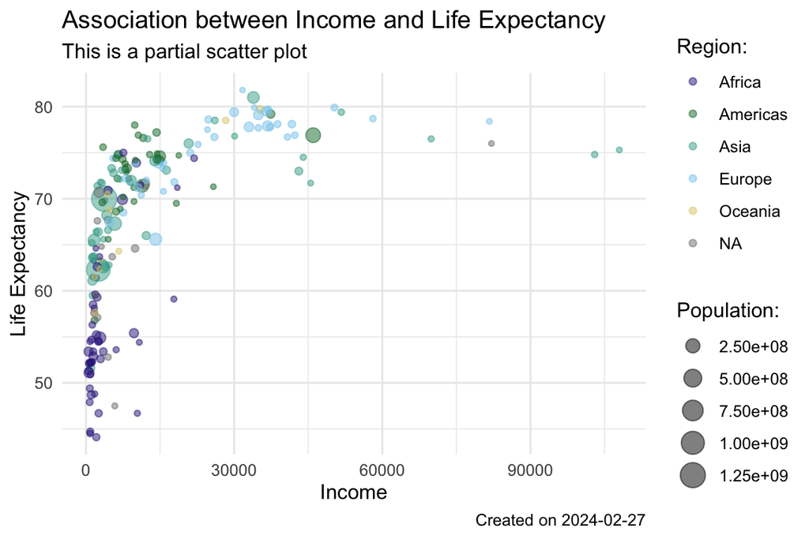

```r
#ggplot
cols1 = c("#332288","#117733","#44AA99","#88CCEE","#DDCC77","#CC6677")
ggplot(data2000, aes(x = income, y = lifeExp,
                 color = region,
                 size = pop)) +
  geom_point(alpha = 0.5) + scale_color_manual(values = cols1) +
  labs(
    x = "Income",
    y = "Life Expectancy",
    # label for legends
    size = "Population:",
    color = "Region:",
    title = "Association between Income and Life Expectancy",
    subtitle = "This is a partial scatter plot",
    caption = paste("Created on", Sys.Date())) +
  theme_minimal()   # minimal theme
```

The graph shows the relation between income and life expectancy of 193 countries/regions in 2000. The size of the points is proportioned to population and colors represent different continents. From this graph, we can find that:

- Most countries that have low life expectancy are in Africa.
- Most countries that have high life expectancy are in Europe.
- When income is under 5,000, life expectancy sharply increases to about 70 years when income increases.
- When income is 5,000 to 30,000, life expectancy continues to increase slowly with income.
- When income is 30,000 to 100,000, life expectancy slightly decreases with income.
- For the countries with longest life expectancy, the income is 30,000 to 40,000 and the population is usually under 250 million.